# petgraph_review

## petgraph review/tutorial

- Author: [Timothy Hobbs](https://timothy.hobbs.cz)
- License: [CC-BY 4.0](https://creativecommons.org/licenses/by/4.0/)
- Written: 10-11.2019
- Send PRs to: [github](https://github.com/timthelion/rust-jupyter)

[project homepage](https://github.com/petgraph/petgraph) ipynb

petgraph is a rust library which allows you to work with graph data structures in rust.

```rust
:dep petgraph = "0.4.13"
```

```rust
:dep petgraph-evcxr = "*"
```

```rust
extern crate petgraph;
use petgraph::graph::Graph;
use petgraph::dot::Dot;
```

```rust
use petgraph_evcxr::draw_graph;
```

I guess I'll start by specifying what kind of graphs we're talking about. We're talking about the datastructure type of graph, not the 'chart' type of graph. For the chart type of graph try the [plotters](https://github.com/38/plotters#trying-with-jupyter-evcxr-kernel-interactively) library.

```rust
:dep plotters = { git = "https://github.com/38/plotters", default_features = false, features = ["evcxr"] }
```

```rust
extern crate plotters;
use plotters::prelude::*;

let figure = evcxr_figure((640, 480), |root| {
    root.fill(&WHITE);
    let mut chart = ChartBuilder::on(&root)
        .caption("Not this type of graph", ("Arial", 50).into_font())
        .margin(5)
        .x_label_area_size(30)
        .y_label_area_size(30)
        .build_ranged(-1f32..1f32, -0.1f32..1f32)?;

    chart.configure_mesh().draw()?;

    chart.draw_series(LineSeries::new(
        (-50..=50).map(|x| x as f32 / 50.0).map(|x| (x, x * x)),
        &RED,
    )).unwrap()
        .label("y = x^2")
        .legend(|(x,y)| PathElement::new(vec![(x,y), (x + 20,y)], &RED));

    chart.configure_series_labels()
        .background_style(&WHITE.mix(0.8))
        .border_style(&BLACK)
        .draw()?;
    Ok(())
});
figure
```

[figure not shown]

This is an example of a graph. You can create a graph in petgraph by initializing a `Graph` struct and adding some nodes and edges to it.

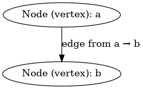

```rust
let mut g : Graph<&str, &str> = Graph::new();
let a = g.add_node("Node (vertex): a");
let b = g.add_node("Node (vertex): b");
g.add_edge(a, b, "edge from a → b");
draw_graph(&g);
```

Graphs are universal datastructures. Every data structure can be represented as a graph. Here are some examples of data structures that can be represented as graphs.

- variables
- lists
- tables
- trees
- ring buffers
- dictionaries

## Variables

A variable can be represented, from a theoretical standpoint, as a singleton graph.

```rust
let mut singleton : Graph<&str, &str, petgraph::Undirected> = Graph::new_undirected();
let singleton_node = singleton.add_node("only value");
draw_graph(&singleton);
```

[output not shown]

## Lists

```rust
let mut list : Graph<&str, &str, petgraph::Undirected> = Graph::new_undirected();
let item1 = list.add_node("a");
let item2 = list.add_node("b");
let item3 = list.add_node("c");
list.add_edge(item1, item2, "");
list.add_edge(item2, item3, "");
draw_graph(&list);
```

[output not shown]

## Tables

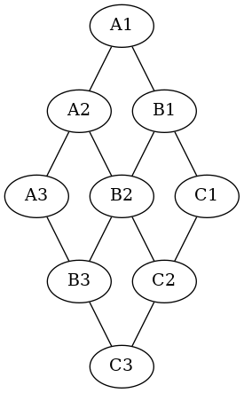

```rust
let mut table : Graph<&str, &str, petgraph::Undirected> = Graph::new_undirected();
let cellA1 = table.add_node("A1");
let cellA2 = table.add_node("A2");
let cellA3 = table.add_node("A3");

let cellB1 = table.add_node("B1");
let cellB2 = table.add_node("B2");
let cellB3 = table.add_node("B3");

let cellC1 = table.add_node("C1");
let cellC2 = table.add_node("C2");
let cellC3 = table.add_node("C3");

// Columns
table.add_edge(cellA1, cellA2, "");
table.add_edge(cellA2, cellA3, "");

table.add_edge(cellB1, cellB2, "");
table.add_edge(cellB2, cellB3, "");

table.add_edge(cellC1, cellC2, "");
table.add_edge(cellC2, cellC3, "");

// Rows
table.add_edge(cellA1, cellB1, "");
table.add_edge(cellB1, cellC1, "");

table.add_edge(cellA2, cellB2, "");
table.add_edge(cellB2, cellC2, "");

table.add_edge(cellA3, cellB3, "");
table.add_edge(cellB3, cellC3, "");

draw_graph(&table);
```

## Trees

```rust
let mut tree : Graph<&str, &str, petgraph::Directed> = Graph::new();
let tree_item1 = tree.add_node("a");
let tree_item2 = tree.add_node("b");
let tree_item3 = tree.add_node("c");
let tree_item4 = tree.add_node("d");
let tree_item5 = tree.add_node("e");
tree.add_edge(tree_item1, tree_item2, "");
tree.add_edge(tree_item1, tree_item3, "");
tree.add_edge(tree_item2, tree_item4, "");
tree.add_edge(tree_item2, tree_item5, "");
draw_graph(&tree);
```

[output not shown]

## Rings

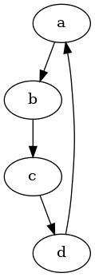

```rust
let mut ring : Graph<&str, &str> = Graph::new();
let ring_item1 = ring.add_node("a");
let ring_item2 = ring.add_node("b");
let ring_item3 = ring.add_node("c");
let ring_item4 = ring.add_node("d");
ring.add_edge(ring_item1, ring_item2, "");
ring.add_edge(ring_item2, ring_item3, "");
ring.add_edge(ring_item3, ring_item4, "");
ring.add_edge(ring_item4, ring_item1, "");
draw_graph(&ring);
```

## Dictionaries

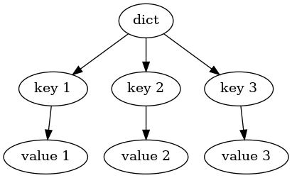

```rust
let mut dict : Graph<&str, &str> = Graph::new();
let core = dict.add_node("dict");

let key1 = dict.add_node("key 1");
let key2 = dict.add_node("key 2");
let key3 = dict.add_node("key 3");

let value1 = dict.add_node("value 1");
let value2 = dict.add_node("value 2");
let value3 = dict.add_node("value 3");

dict.add_edge(core, key1, "");
dict.add_edge(core, key2, "");
dict.add_edge(core, key3, "");

dict.add_edge(key1, value1, "");
dict.add_edge(key2, value2, "");
dict.add_edge(key3, value3, "");
draw_graph(&dict);
```

## Basic petgaph usage

In petgraph there are various ways of storing a graph. The simplest is to use the [`Graph`](https://docs.rs/petgraph/0.4.13/petgraph/graph/struct.Graph.html) data type. `Graph`s can be either Directed or Undirected. (Note: Graphs are stored the same way whether they are Directed or Undirected. All graphs are stored internally as directed graphs. The only difference is the behavior of some algorithms such as the shortest path algorithms. )

You can initialize a directed graph with the statement:

```
let mut directed_graph : Graph<&str, &str> = Graph::new();
```

You can initialize an undirected graph with the statement:

```
let mut undirected_graph : Graph<&str, &str, petgraph::Undirected> = Graph::new_undirected();
```

You may have noticed that we specify the `Graph`'s type with two type parameters `&str` and `&str`.

The first parameter is the `Node` weight. This is the data that is associated with the node. Weights are sometimes refered to as labels.

The second parameter is the `Edge` weight.

With petgraph you can store any type of data as node or edge weights. Lets create a simple social graph to demonstrate this fact.

```rust
use std::fmt;

#[derive(Debug, Copy, Clone)]
struct Person<'a> {
    name: &'a str,
    age: u8,
}

#[derive(Debug, Copy, Clone)]
enum Relationship {
    Friend,
    Parent,
    Sibling,
    Child,
    Boss,
}

impl<'a> fmt::Display for Person<'a> {
    fn fmt(&self, f: &mut fmt::Formatter<'_>) -> fmt::Result {
        write!(f, "{}, {}", self.name, self.age)
    }
}

impl fmt::Display for Relationship {
    fn fmt(&self, f: &mut fmt::Formatter<'_>) -> fmt::Result {
        write!(f, "{:?}", self)
    }
}
```

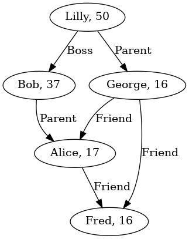

```rust
let mut social_graph : Graph<Person, Relationship> = Graph::new();

let bob = social_graph.add_node(Person{name: "Bob", age: 37});
let alice = social_graph.add_node(Person{name: "Alice", age: 17});
social_graph.add_edge(bob, alice, Relationship::Parent);

let lilly = social_graph.add_node(Person{name: "Lilly", age: 50});
social_graph.add_edge(lilly, bob, Relationship::Boss);

let george = social_graph.add_node(Person{name: "George", age: 16});
social_graph.add_edge(george, alice, Relationship::Friend);
social_graph.add_edge(lilly, george, Relationship::Parent);

let fred = social_graph.add_node(Person{name: "Fred", age: 16});
social_graph.add_edge(george, fred, Relationship::Friend);
social_graph.add_edge(alice, fred, Relationship::Friend);

draw_graph(&social_graph);
let original_social_graph = social_graph.clone();
```

## Basic graph operations

The most basic graph operations can be found directly as methods on the [`Graph`](https://docs.rs/petgraph/0.4.13/petgraph/graph/struct.Graph.html) struct.

One of the most common methods is the [`map`](https://docs.rs/petgraph/0.4.13/petgraph/graph/struct.Graph.html#method.map) method which applies given functions to each node and edge weight in the graph. This method **creates a new graph** and the functions can **change the type of the weights**.

```
pub fn map<'a, F, G, N2, E2>(
    &'a self,
    node_map: F,
    edge_map: G
) -> Graph<N2, E2, Ty, Ix> where
    F: FnMut(NodeIndex<Ix>, &'a N) -> N2,
    G: FnMut(EdgeIndex<Ix>, &'a E) -> E2,
```

Here we increment the age of each person in the social graph.

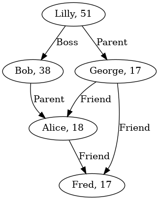

```rust
let mut social_graph_a_year_later = social_graph.map(
    |_, p| {
        let mut p = p.clone();
        p.age += 1;
        p
    },
    |_, x| x.clone()
);
draw_graph(&social_graph_a_year_later);
```

You can also **modify the weights in place** using the [`node_weights_mut`](https://docs.rs/petgraph/0.4.13/petgraph/graph/struct.Graph.html#method.node_weights_mut) and [`edge_weights_mut`](https://docs.rs/petgraph/0.4.13/petgraph/graph/struct.Graph.html#method.edge_weights_mut) iterators. This method **does not allow you to change the types of the weights**.

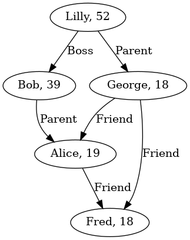

```rust
for person in social_graph_a_year_later.node_weights_mut(){
    person.age += 1;
}
draw_graph(&social_graph_a_year_later);
```

There are a large number of methods provided for `Graph`. Too many to list here. The last thing I'll mention about these methods is that methods wich remove nodes, such as [`filter_map`](https://docs.rs/petgraph/0.4.13/petgraph/graph/struct.Graph.html#method.filter_map) and [`remove_node`](https://docs.rs/petgraph/0.4.13/petgraph/graph/struct.Graph.html#method.remove_node) remove edges which are attached to the removed nodes, rather than leaving them dangling.

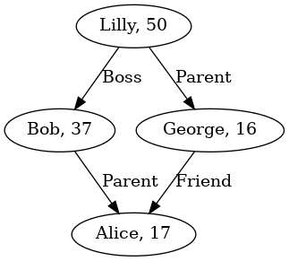

```rust
social_graph.remove_node(fred);
draw_graph(&social_graph);
```

## Graph algorithms

Beyond the basic graph operations, petgraph also provides an array of graph algorithms in the module [`algo`](https://docs.rs/petgraph/0.4.13/petgraph/algo/index.html). These operations are well known and you can find their descriptions in most graph textbooks or on wikipedia.

I'll start by describing the functions `is_cyclic_directed` and `is_cyclcic_undirected`. These functions are very important, because the distinction between cyclic graphs and acyclic graphs plays a big role in determining which other algorithms can be applied to the graph.

```rust
use petgraph::algo::*;
```

```rust
println!("Is tree cyclic? {}", is_cyclic_undirected(&tree));
println!("Is social_graph cyclic? {}", is_cyclic_directed(&social_graph_a_year_later));
println!("Is social_graph cyclic if we ignore edge direction? {}", is_cyclic_undirected(&social_graph_a_year_later));
println!("Is ring cyclic? {}", is_cyclic_directed(&ring));
```

```
Is tree cyclic? false
Is social_graph cyclic? false
Is social_graph cyclic if we ignore edge direction? true
Is ring cyclic? true
```

## Revisiting the types of graph: What is a DAG

One constant of computer science is that data structures that are simple are used far more frequently than those which are complex. I started this article by claiming that graphs are the universal data structure. I went on to show how a the petgraph library can represent any datastructure from a variable, to a list, to a table, to a tree, to a dictionary/hashmap. All of these data structures, however, exist in far more efficent forms either directly as built in types in rust, or as provided in third party libraries. If you need to represent a list, tree or a table and nothing else, you should **never** use petgraph to do so. You should always use the most limited possible data structure which is capable of representing your data because doing so allows your compiler and typechecker to help you prevent bugs. If you write a function that takes a tree and does something with it, and it's type signature looks like:

```
fn cut_tree(tree: Tree) -> Stump {
```

Then you only need to test your function for various possible trees that could be given to that function. The type checker will ensure that only trees are passed to that function, and you do not need to wory about edge cases where something other than a tree might have been passed to it. But if your type signature looks like:

```
fn cut_tree(tree: Graph) -> Stump {
```

You'll need to test for all sorts of data structures that aren't trees in order to be sure that your program will behave correctly and will not crash.

The simplest, and therefore most common type of data structure that you actually need the power of petgraph to represent is called a **DAG** or **D**irected **A**cyclic **G**raph. DAGs are a lot like trees but their branches can merge.

This is a tree:

```rust
draw_graph(&tree);
```

[output not shown]

And this is a DAG

```rust
let mut dag = tree.clone();
let dag_item_f = dag.add_node("f");
dag.add_edge(tree_item4, dag_item_f, "");
dag.add_edge(tree_item5, dag_item_f, "");
draw_graph(&dag);
```

[output not shown]

There is a certain hierarchy of data structures in computer science. All singletons are lists, all lists are tables. All lists are also trees. All trees (IFF they're edges are directed) are DAGs.

You can tell if a graph is a tree by running the `is_cyclic_undirected` function on it. If this function returns `false`, you're working with a tree.

```rust
use petgraph::*;
```

```rust
fn is_tree<'a, N: 'a, E: 'a, Ty, Ix>(g: &'a Graph<N, E, Ty, Ix>) -> bool
 where
  Ty: EdgeType,
  Ix: petgraph::graph::IndexType
{
    return !is_cyclic_undirected(g);
}

println!("Is tree a tree? {}", is_tree(&tree));
println!("Is dag a tree? {}", is_tree(&dag));
```

```
Is tree a tree? true
Is dag a tree? false
```

You can tell if a graph is a DAG if it is directed and `is_cyclic_directed` returns `false`.

```rust
fn is_dag<'a, N: 'a, E: 'a, Ty, Ix>(g: &'a Graph<N, E, Ty, Ix>) -> bool
 where
  Ty: EdgeType,
  Ix: petgraph::graph::IndexType
{
    return g.is_directed() && !is_cyclic_directed(g);
}

println!("Is tree a DAG? {}", is_dag(&tree));
println!("Is dag a DAG? {}", is_dag(&dag));
println!("Is ring a DAG? {}", is_dag(&ring));
```

```
Is tree a DAG? true
Is dag a DAG? true
Is ring a DAG? false
```

## What are some examples of DAGs in the wild?

- **POSIX file trees**: At a low level, the POSIX file system is implemented as a DAG. I know, we refer to the directory hierarchy as a file *tree*, but hard links allow for the merging of branches which makes them not trees in all cases. Since hard links can only be used to link two files, and not directories, cycles cannot be formed. At a higher level, if you take symlinks (which are actually just a special kind of file) into account, file trees are not even DAGs, but generalized graphs.
- **Dependency graphs**: Traditional package managers in which packages depend on one another, end up representing a DAG of packages. You cannot have cycles in such a graph, because the package manager never installs a package before it's dependencies have been installed.
- **Makefiles**: Makefiles are another case of doing steps which depend on eachother.
- **init system services**: In init systems such as sysv init and systemd the same property applies, that you start services who's dependencies have started first.
- **Rust struct declarations**: In rust, the structs which you have declared form a DAG. They cannot form a cycle because rust needs to know how large a struct within a struct is at compile time. This can be worked around by including pointers/references to other structs rather than including them directly.
- **Git commits**: Just the vocabulary of `branches` should suggest that there is a tree of git commits, but the existance of `merge` commits means that we're working with a DAG.
- **IPFS nodes**: In IPFS, which is a distributed Hashed DAG there are no cycles.

## Why are DAGs so common?

There are two properties at play here which make DAGs extremely usefull in computer science. The first is `watershedding`. Watershedding is the idea that some regions of your graph are clearly isolated from others. Remember the origional dag I mentioned?

```rust
draw_graph(&dag);
```

[output not shown]

There is no way to get from `e` to `b`. That's a good thing in some cases, and is the reason why POSIX file DAGs are DAGs and not generalized graphs. You want to be certain that when you type in

```
$ rm -rf /a/b/e
```

You'll be deleting only `e` and `f` and not your entire file system. If there was ever a loop like this:

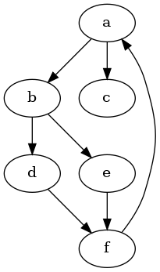

```rust
let mut general_graph = dag.clone();
general_graph.add_edge(dag_item_f, tree_item1, "");
draw_graph(&general_graph);
```

Then you could end up deleting all your files accidentally, and that would make POSIX harder to use and less predictable.

The second reason why DAGs are so common is more fundamental. With DAGs there is always a **clear order of operations**. That doesn't just make it easier to work with DAGs than general graphs, it makes a lot of things possible which simply cannot done otherwise.

The algorithm which tells you the order of operations for a DAG is called a **topological sort**, and is defined in petgraph's algo library as the [`toposort`](https://docs.rs/petgraph/0.4.13/petgraph/algo/fn.toposort.html) function.

```rust
draw_graph(&tree);
```

[output not shown]

```rust
fn print_topo_sort<'a, Ty, Ix>(g: &'a Graph<&'a str, &'a str, Ty, Ix>)
 where
  Ty: EdgeType,
  Ix: petgraph::graph::IndexType
{
    match toposort(g, None){
        Ok(order) => {
            print!("Sorted: ");
            for i in order {
                 g.node_weight(i).map(|weight| {
                     print!("{}, ", weight);
                     weight
                 });
             }
        },
        Err(err) => {
            g.node_weight(err.node_id()).map(|weight|
                println!("Error graph has cycle at node {}", weight));
        }
    }
    println!("");
}

print_topo_sort(&tree);
```

```
Sorted: a, c, b, e, d,
```

Note that topological sorts are by their very nature non-deterministic functions. The only guarantee is that dependencies come before dependents, but when two nodes are at the same level, they can come in any order. Here, the output is `Sorted tree: a, c, b, e, d`, but it could just as easilly have been `Sorted tree: a, b, c, d, e`.

```rust
draw_graph(&dag);
print_topo_sort(&dag);
```

[output not shown]

```
Sorted: a, c, b, e, d, f,
```

During actual execution, topoloical sorting is less common than you might think. The thing is that dependency DAGs differ from TODO lists in that dependency DAGs in that their execution can be easilly parallelized. In the example above, the `c` and `b` branches can be executed symultaneously, as can the `d` and `e` tasks. There are a number of strategies for executing DAGs in parallel. I won't be describing them here.

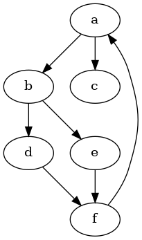

```rust
draw_graph(&general_graph);
```

```rust
print_topo_sort(&general_graph);
```

```
Error graph has cycle at node f
```

## DAGs are reversible

If you reverse the direction of the edges in a DAG, you end up with a DAG. This is an important thing to understand when working on a package manager, because if you want to uninstall a package and all of it's dependents, then you need to uninstall the dependents first. You can reverse the DAG with the [`reverse`](https://docs.rs/petgraph/0.4.13/petgraph/graph/struct.Graph.html#method.reverse) method, or, if you are working with a topolgical sort, simply by reversing the output of `toposort`.

## More general graphs - Shortest path algorithms

The other algorithms provided by petgraph are applicable to more general graphs. The best known are the shortest path and existant path algorithms. Specifically, the Dijkstra algorithm is widely taught as being a generally usefull and elegant algorithm in schools. I mentioned earlier that the values associated with edges in petgraph are called `weights` rather than `labels` as is done elsewhere. This is because these values can be used to calculate edge `cost` when evaluating the shortest distance algorithms. In the traditional map based questions, this cost is the literal distance (or travel time) between points. This cost can also be something else.

Here are some example graphs that you might use shortest length algorithms on:

- A computer network where the edge weights are the pings
- A computer network where the edge weights are the monitary cost per byte
- A computer network where the edge weights are both the pings AND the monitary cost per byte
- A network of tax juristictions where the edge weights are tarifs and other taxes and fees
- A market where the edge weights are cost of exchanging one good or security for another

All of these can be modeled by petgraph, however, **you probably shouldn't use petgraph for geospatial graphs** you should use a specialized library or database for this. Postgres, for example, can store geospatial data using the postgis addon and use [pgRouting](http://pgrouting.org/) to find the shortest paths. Specialized geospatial routing engines are able to use spatial heuristics such as direction to significantly speed up route finding.

Petgraph provides 3 shortest path algorithms. (Links are to wikipedia)

- [Dijkstra](https://en.wikipedia.org/wiki/Dijkstra%27s_algorithm)
- [astar](https://en.wikipedia.org/wiki/A*_search_algorithm)
- [bellman_ford](https://en.wikipedia.org/wiki/Bellman%E2%80%93Ford_algorithm)

## Dijkstra

Here is [the type declaration](https://docs.rs/petgraph/0.4.13/petgraph/algo/fn.dijkstra.html) for petgraph's dijstra.

```
pub fn dijkstra<G, F, K>(
    graph: G,
    start: G::NodeId,
    goal: Option<G::NodeId>,
    edge_cost: F
) -> HashMap<G::NodeId, K> where
    G: IntoEdges + Visitable,
    G::NodeId: Eq + Hash,
    F: FnMut(G::EdgeRef) -> K,
    K: Measure + Copy,
```

Notice how the function returns a HashMap? What's up with that? A HashMap is not a path. It should be noted that Dijstra and astar are actually the same algorithm and the Dijstra implementation provided by petgraph is kind of useless, so I'll be ignoring the provided `dijstra` function.

## A* (astar)

[docs](https://docs.rs/petgraph/0.4.13/petgraph/algo/fn.astar.html)

```
pub fn astar<G, F, H, K, IsGoal>(
    graph: G,
    start: G::NodeId,
    is_goal: IsGoal,
    edge_cost: F,
    estimate_cost: H
) -> Option<(K, Vec<G::NodeId>)> where
    G: IntoEdges + Visitable,
    IsGoal: FnMut(G::NodeId) -> bool,
    G::NodeId: Eq + Hash,
    F: FnMut(G::EdgeRef) -> K,
    H: FnMut(G::NodeId) -> K,
    K: Measure + Copy,
```

As I said, A* and Dijkstra are the same. The differenece is the `estimate_cost` function. This function allows the algorithm to have some heuristics about which direction to start looking in. It is especially usefull when using geospatial data. If you are trying to find the shortest path in terms of distance and you know the x y coordinates of each node in your graph, `estimate_cost` should return the distance as a crow flies from the given node to the start node. If you're looking for the shortest path in terms if travel time then you should take the crow flies distance and divide it by the top speed limit for the given mode of transportation. If you are doing network routing and you happen to be lucky enough to know the coordinates of each node in the network, then the speed limit is C, aka the speed of light. If you don't have any way of determining a heuristic, then return `0` and you have the Dijkstra algorithm.

Remember that old social graph example? Let's apply A* to it. Imagine that that kid Fred shares some sensitive private information on an employee of Lilly's. What is the most likely route by which the info got out? Lets say that such information is most likely to be shared between friends (with a virtual cost of 1), followed by sharing between familly members (lets give that a virtual cost of 2), and finally quite unlikely to be shared between collegues because they are accutely aware that sharing such information is illegal and wrong (cost of 5).

Lets start by declaring the cost and heuristic functions for our social graph.

```rust
fn rumor_spreading_cost(er : graph::EdgeReference<Relationship>) -> u32 {
    match *er.weight() {
        Relationship::Friend => 1,
        Relationship::Parent => 2,
        Relationship::Sibling => 2,
        Relationship::Child => 2,
        Relationship::Boss => 5,
    }
}
```

```rust
fn no_clue_heuristic<N>(nid: N) -> u32 {
    0
}
```

Now we'll get to actually calling the astar function. To find out how the rumor spread.

```rust
let (cost, path) = astar(
    &original_social_graph,
    lilly,
    |n| n == fred,
    rumor_spreading_cost,
    no_clue_heuristic,
).unwrap();

for node_ix in path.iter() {
    println!("{:?}", original_social_graph.node_weight(*node_ix).unwrap());
}
```

```
Person { name: "Lilly", age: 50 }
Person { name: "George", age: 16 }
Person { name: "Fred", age: 16 }
```

```
()
```

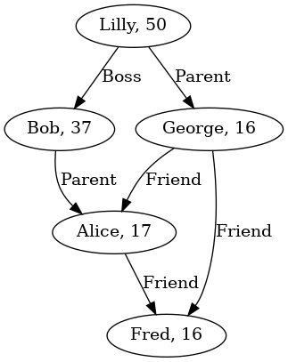

```rust
draw_graph(&original_social_graph);
```

So now we can see that the most likely scenario is that Lilly told her son George the private info who then told Fred.

## Bellman Ford

[docs](https://docs.rs/petgraph/0.4.13/petgraph/algo/fn.bellman_ford.html)

```
pub fn bellman_ford<G>(
    g: G,
    source: G::NodeId
) -> Result<(Vec<G::EdgeWeight>, Vec<Option<G::NodeId>>), NegativeCycle> where
    G: NodeCount + IntoNodeIdentifiers + IntoEdges + NodeIndexable,
    G::EdgeWeight: FloatMeasure,
```

Bellman Ford differs from A*/Dijkstra in that it supports negative edge weights. This is usefull in cases such as when searching for optimal trade paths, because in some cases crossing a tax border can be a good thing due to the existance of subsidies. Ironically, Bellman Ford doesn't fair perfectly in this case, because it doesn't know how to deal with a situation where there is a negative edge weight cycle. Such a situation would lead to an infintely long shortest path ;). That sometimes happens in real life trade though, a country might grant an outgoing subsidy on a good while neglecting to impose an equal and oposite incomming tarif and we see ships sailing in circles just to collect infinite subsidies. `bellman_ford` does, however, return a `Result` with a `NegativeCycle` outcome if such a cycle does exist. Perhaps legislators should use petgraph's `bellman_ford` algorithm to detect such cycles before writing subsidies into law.

One of the first things I noticed when looking at `bellman_ford` is that rather than taking an `edge_cost` function like `astar` does, it just expects edge weights in the graph to be of the type `G::EdgeWeight: FloatMeasure`. This isn't that big of a deal, we can use the `map` method to map edges of any type to floats, but it does lead to potential memory inefficiency. `map` returns an new graph, which means that in order to use `bellman_ford` we may need to have the graph in memory twice for the duration of the path finding procedure, and that merely because of a design choice.

Another thing I noticed is that `bellman_ford` returns a tuple of two Vecs. One contains the length of each path, the other contains the "predecessor". Here is the exact docstring:

" On success, return one vec with path costs, and another one which points out the predecessor of a node along a shortest path. The vectors are indexed by the graph's node indices. "

For a while I didn't understand how this works. What is happening here, is that you should think of the second `Vec` as a map which maps nodes to nodes. If the `Option` is `None` that means the node is unreachable. If it is `Some(x)` that means that there is a path to that node and the previous node in that path is x. If that Vec looks like `let predicessors = vec![None,Some(0),Some(1),Some(2)]` that means that:

- node with index 0 is unreachable
- node 1 can be best reached via node 0
- node 2 can be best reached via node 1
- node 3 can be best reached via node 2

  Note that the source node is considered unreachable unless there is an actual path to it.

Lets imagine a situation, again in our social graph, in which Lilly wants to send money to people. There are different tax liabilities depending on her relationship to that person. There is a flat 30% income tax in this theoretical country and no gift tax between friends.

- Employee need to pay a %30 income tax on all money comming from a boss
- If a dependent (child) gets money up to two thirds of the money can be deducted from the parents income
- Small transfers between friends are not taxed
- Small transfers from children to parents are taxed at %20 to prevent a negative tax cycle

Lets figure out the best way for Lilly to send a christmass bonus to her employee Bob.

The first thing we need to do is realize that our social graph is directed, but it makes sense that friends should be able to transfer funds in either direction. Also, we haven't added Child → Parent relationships to our graph. We're going to need to add new edges based on the existing edges, to make these relationships bidirectional. Note, that we can't just convert the graph to a non-directed graph because in this case, the relationships are NOT symetrical from a taxation standpoint.

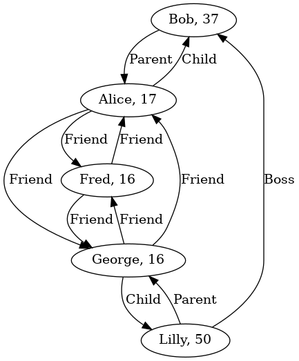

```rust
let mut bdsg = original_social_graph.clone(); //bidirectional_social_graph
for edge_ix in bdsg.edge_indices() {
    let (source, dest) = bdsg.edge_endpoints(edge_ix).unwrap();
    match *bdsg.edge_weight(edge_ix).unwrap() {
        Relationship::Parent => {
                bdsg.add_edge(dest, source, Relationship::Child);
        },
        Relationship::Friend => {
                bdsg.add_edge(dest, source, Relationship::Friend);
        },
        Relationship::Sibling => {
                bdsg.add_edge(dest, source, Relationship::Sibling);
        },
        _ => (),
    }
}
draw_graph(&bdsg);
```

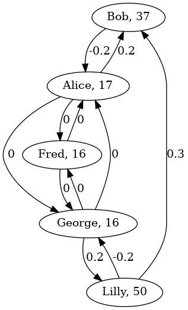

```rust
let social_graph_with_tax_costs = bdsg.map(
    |_, nw| nw.clone(),
    |_, ew| match ew {
        Relationship::Friend => 0.0,
        Relationship::Parent => -0.2,
        Relationship::Sibling => 0.0,
        Relationship::Child => 0.2,
        Relationship::Boss => 0.3,
    },
);
draw_graph(&social_graph_with_tax_costs);
```

```rust
println!("{:?}", bellman_ford(&social_graph_with_tax_costs, lilly));
```

```
Ok(([0.0, -0.2, 0.0, -0.2, -0.2], [Some(NodeIndex(1)), Some(NodeIndex(3)), None, Some(NodeIndex(2)), Some(NodeIndex(3))]))
```

So we have this output from the `bellman_ford` function, but how do we actually use it? How do we turn those two lists into an actual tax optimal path for sending money to Bob? First we need to understand what the "predicessor's" list actual is. It's a [shortest-path tree](https://en.wikipedia.org/wiki/Shortest-path_tree). We can visualize this tree as follows:

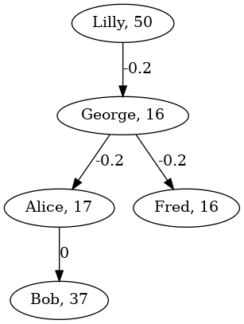

```rust
let (sgwtc_costs, sgwtc_predicessors) = bellman_ford(&social_graph_with_tax_costs, lilly).unwrap();
let mut spt_ = bdsg.clone();  //spt = Shortest path tree
spt_.clear_edges();
let mut spt = spt_.map(
    |_, nw| nw.clone(),
    |_, _| 0.0,
); // Use map to change type of edge weights to float.
let mut i = 0;
for op_node_ix in sgwtc_predicessors.iter() {
    match op_node_ix {
        Some(node_ix) => {
            spt.add_edge(*node_ix, graph::NodeIndex::new(i), sgwtc_costs[i]);
        }
        None => ()
    };
    i += 1;
}
draw_graph(&spt);
```

Since this is a review and not just a manual, I'd like to take a moment to point out a mistake that has been made in the api for `bellman_ford`. The function returns a tuple of two `Vec`s of identical length. This should *never* be done. The proper way to do things is to return ONE Vec of tuples. That way the compiler will ensure that for every path there is at least one, and exactly one, cost. This way, the for loop that I just wrote assumes that there will be a element at index `i` in `sgwtc_costs` but this is only an assumption, not a guarantee by the compiler. If that index did not exist, my code would crash. This is an easy mistake to make for a person comming from a language which is strongly typed, like C but not richly typed. You can have a "strongly typed" language where the only type is a string. Or perhaps `void *` ;) or `interface {}`. While you might feel that you gain some guarantees by using such a "strongly typed" language, the truth is, that guarantees about type saftey always come when a strongly typed language is used in concert with it's rich type system in order to construct types which provide the guarantees that you desire. Rust is a richly typed language and is capable of providing many detailed guarantees. One such guarantee is that in a list of pairs every item has it's pair.

Now back to work. I can see clearly by looking at the visualization of the shortest path tree that the best way for Lilly to send money to Bob is to give a tax deductible payment to her son George, who will then give a tax free gift to his friend Alice who will then give the money to Bob.

But how do we find that path programatically?

*Note that nothing in this article is intended as advice on how to evade taxes.*

Simple. We start at Bob's place in the predicessors Vec and we walk backwards.

```rust
let mut optimal_path_to_bob = vec![];
let mut n = bob.index();
while n != lilly.index() {
    match sgwtc_predicessors[n]{
        Some(node_ix) => {
            optimal_path_to_bob.push(node_ix);
            n = node_ix.index();
        }
        None => ()
    }
};

optimal_path_to_bob.reverse();

for step in optimal_path_to_bob.iter() {
    println!(
        "{}",
        social_graph_with_tax_costs.node_weight(*step)
            .unwrap()
            .name
    );
};
```

```
Lilly
George
Alice
```

## Minimum spanning trees

In 1926, the Western Moravian Electric company (Západomoravsé Elektrárny) was planing for the electrification of west Moravia (Czechoslovakia), when an employee by the name of Jindřich Saxel came to young mathematician Dr. Otakar Borůvka with a problem. How could they lay out the electrical grid in such a way that the wires would be as short as possible? Doing so would both save money in instalation costs and reduce transmission losses ([citation](https://dml.cz/bitstream/handle/10338.dmlcz/401280/SingleBooks_16-1996-1_13.pdf)).

This question lead Borůvka to develop what is refered to as Borůvka's algorithm for finding the minimum spanning tree of a graph. At the time though, graphs weren't well known in the literature, and Borůvka's two papers on the subject did not refer to graphs or trees at all, being titled

"[a Certain Problem of Minimalization](https://dml.cz/bitstream/handle/10338.dmlcz/500114/Boruvka_01-0000-6_1.pdf)"(Czech).

and

"[A Note on solving the problem of cost effective construction of electroconductive networks](https://dml.cz/bitstream/handle/10338.dmlcz/500188/Boruvka_02-0000-1_1.pdf)"(Czech)

Here is how his algorithm worked.

First he layed out all of the towns that ought to be connected as a set of points on a peice of paper.

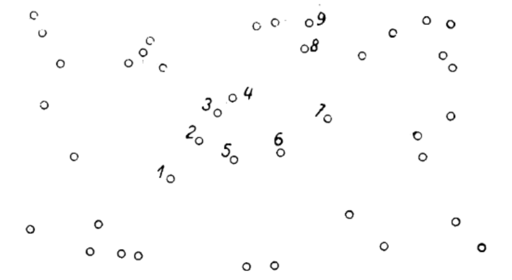

Then he looked at each point and drew a line between that point and its closest geometric neighbor.

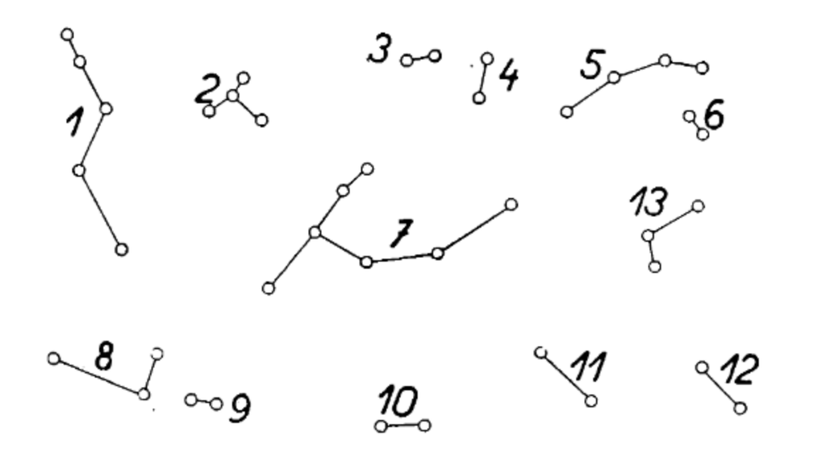

Now he had a set of 13 clumps of points to work with. He then looked at each clump and drew a line possible so as to connect that clump to a non-connected neighboring clump.

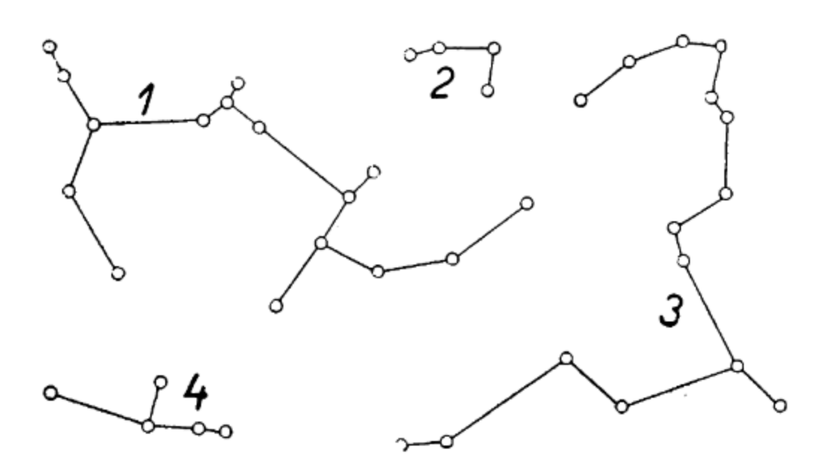

He repeated this process until there were no non-connected clumps left.

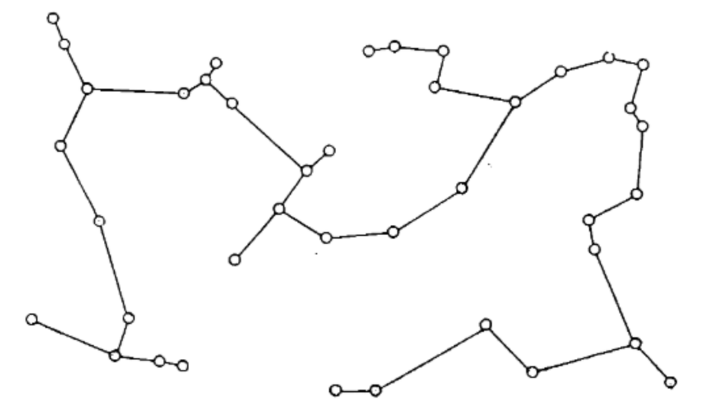

(Images taken from the origional paper on the construction of electric grids)

This gave him a minimum spanning tree for connecting those points. That is, the tree of electrical wires that is as short as possible while still connecting all of the towns.

You can think of his algorithm as staring with a set of points (vertexes) and adding edges based on a set of heuristics. Or you can think of his algorithm as starting with a [Complete graph](https://en.wikipedia.org/wiki/Complete_graph) and selecting vertexes to be included in the MST. Alterations of Borůvka's algorithm are still used today.

A more realistic thing to do would be to actually take existing geography into account and start with real existing "edges" such as roads and rail lines. The resulting MST would be more practical for use when constructing the electric grid and fits better with petgraph's MST algorithm, petgraph being a graph library afterall.

Lets build a graph of Western Moravia using train lines and majorish roads as edges. I used the service mapy.cz to find modern road distances. Distances are in kilometers.

[figure not shown]

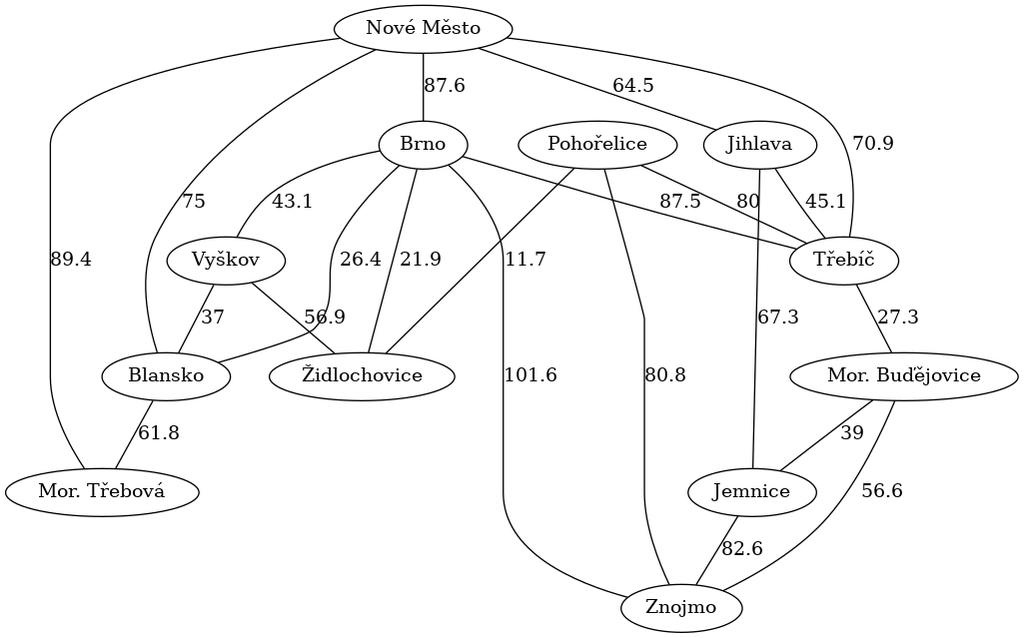

```rust
let mut moravia : Graph<&str, f32, petgraph::Undirected> = Graph::new_undirected();
let brno = moravia.add_node("Brno");
let zdlch = moravia.add_node("Židlochovice");
let pohor = moravia.add_node("Pohořelice");
let vysko = moravia.add_node("Vyškov");
let blansk = moravia.add_node("Blansko");
let trebic = moravia.add_node("Třebíč");
let mbud = moravia.add_node("Mor. Buďějovice");
let jihl = moravia.add_node("Jihlava");
let jemn = moravia.add_node("Jemnice");
let znojmo = moravia.add_node("Znojmo");
let novmest = moravia.add_node("Nové Město");
let mtreb = moravia.add_node("Mor. Třebová");
moravia.add_edge(brno, trebic, 87.5);
moravia.add_edge(brno, zdlch, 21.9);
moravia.add_edge(brno, vysko, 43.1);
moravia.add_edge(brno, blansk, 26.4);
moravia.add_edge(pohor, zdlch, 11.7);
moravia.add_edge(pohor, trebic, 80.0);
moravia.add_edge(blansk, mtreb, 61.8);
moravia.add_edge(trebic, mbud, 27.3);
moravia.add_edge(mbud, znojmo, 56.6);
moravia.add_edge(brno, znojmo, 101.6);
moravia.add_edge(mbud, jemn, 39.0);
moravia.add_edge(jihl, trebic, 45.1);
moravia.add_edge(jihl, jemn, 67.3);
moravia.add_edge(jemn, znojmo, 82.6);
moravia.add_edge(pohor, znojmo, 80.8);
moravia.add_edge(novmest, jihl, 64.5);
moravia.add_edge(novmest, brno, 87.6);
moravia.add_edge(novmest, trebic, 70.9);
moravia.add_edge(novmest, blansk, 75.0);
moravia.add_edge(novmest, mtreb, 89.4);
moravia.add_edge(vysko, blansk, 37.0);
moravia.add_edge(vysko, zdlch, 56.9);
draw_graph(&moravia);
```

Now we run the [`min_spanning_tree`](https://docs.rs/petgraph/0.4.13/petgraph/algo/fn.min_spanning_tree.html) function. This uses [Kruskal's algorithm](https://en.wikipedia.org/wiki/Kruskal%27s_algorithm) rather than Borůvka's. That's not terribly important. The results are just as good. (Though the output may not be the same, since there can be more than one valid MST for a given graph.)

Interestingly, the `min_spanning_tree` function doesn't return a tree. Indeed, the function itself doesn't actually **do** anything of note. Instead it returns an [`Iterator`](https://doc.rust-lang.org/std/iter/trait.Iterator.html) which basically iterates the nodes and edges of the MST, though even that is not precise. It actually iterates the edges of the MSF, the Min Spanning Forest, because if your graph is not [connected](https://en.wikipedia.org/wiki/Connectivity_%28graph_theory%29) it is obviously impossible to create just one tree that spans the entire graph.

The iterator spits out Items of type [`Element<G::NodeWeight, G::EdgeWeight>`](https://docs.rs/petgraph/0.4.13/petgraph/data/enum.Element.html).

```
pub enum Element<N, E> {
    Node {
        weight: N,
    },
    Edge {
        source: usize,
        target: usize,
        weight: E,
    },
}
```

As far as I can tell, you have to figure out if you're working with just one MST or a whole forest of them by yourself.

Notes:

- The heavy lifting is done during the iteration, not during the origional function call.
- The `min_spanning_tree` function does not take direction into account, so if you are looking for a directed version of the algorithm, petgraph doesn't provide one at this time.

We can get a Graph out of this iterator using the `from_elements` method of `Graph`. We can find out how much electrical wire we'll need by summing the edge weights of the resulting graph.

```rust
use petgraph::data::*;
```

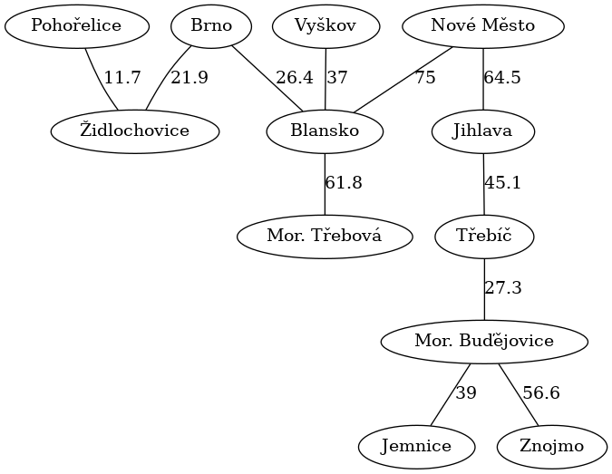

```rust
let moravia_mst : Graph<&str, f32, petgraph::Undirected>
  = Graph::from_elements(min_spanning_tree(&moravia));
draw_graph(&moravia_mst);
```

```rust
let mut wire_length = 0.0;
for edge in moravia_mst.raw_edges() {
    wire_length += edge.weight;
}
println!("Total wire length: {} Km", wire_length);
```

```
Total wire length: 466.3 Km
```

```
()
```

Now it should be noted that Borůvka was trying to do two things. He was trying to reduce the total amount of wire needed **AND** he was trying to reduce transmission losses. Transmission losses are not, however, dictated by overall wire length, but rather average wire length between the consumer and the power plant. We can find the average wire length for the MST we just found by using the built in `dijkstra` shortest path to each node algorithm (I know, earlier I said the output was useless because it doesn't give a path. We don't need one in this case, just the lengths.)

```rust
{
    let mut numerator = 0.0;
    let mut denominator = 0.0;
    for (_, distance) in dijkstra(&moravia_mst, brno, None, |w| *w.weight()) {
        numerator += distance;
        denominator += 1.0;
    }
    println!("Average distance: {}", numerator/denominator);
}
```

```
Average distance: 126.85834
```

```
()
```

That's a rather high average distance. If you look at the generated MST, Brno is way off to one side of the graph, making electrical transmission much less effective. What happens, if instead of using an MST algorithm we use a shortest path from Brno algorithm?

```rust
{
    let mut numerator = 0.0;
    let mut denominator = 0.0;
    for (_, distance) in dijkstra(&moravia, brno, None, |w| *w.weight()) {
        numerator += distance;
        denominator += 1.0;
    }
    println!("Average distance: {}", numerator/denominator);
    println!("Total distance: {}", numerator);
}
```

```
Average distance: 74.25833
Total distance: 891.1
```

```
()
```

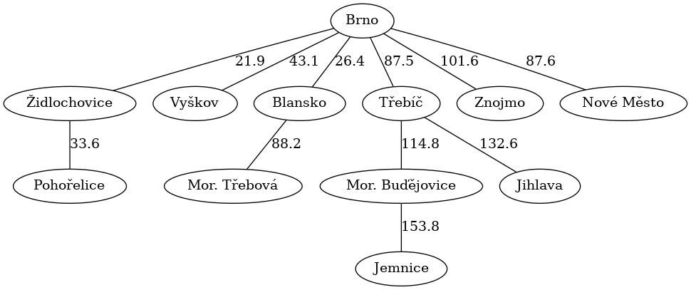

```rust
{
    let (costs, predicessors) = bellman_ford(&moravia, brno).unwrap();
    let mut spt = moravia.clone();  //spt = Shortest path tree
    spt.clear_edges();
    let mut i = 0;
    for op_node_ix in predicessors.iter() {
        match op_node_ix {
            Some(node_ix) => {
                spt.add_edge(*node_ix, graph::NodeIndex::new(i), costs[i]);
            }
            None => ()
        };
        i += 1;
    }
    draw_graph(&spt);
}
```

Just glancing at the two trees, the minimum spaning tree is like a long nudle, where as the shortest distance tree is much more treeish. The shortest distance tree is more resiliant to edge breakage. In the later tree, if the edge between Brno and Blansko is broken, only two cities lose power, but in the minimum spanning tree, the same breakage causes nine cities to lose power.

## Graph isomorphism

When I was reading the paper by Borůvka on optimizing the electrical grid I noticed what appeared to be a grave error. The last image, picture 4 didn't match the others. I stared at the paper for quite a while before I realized that a simple printing error had occured. The printers had flipped the image upside down (I corrected this in the image I included in this review). One of the biggest problems with graphs is that they do not have any natural orientation. There is no such thing as a graph being right side up or upside down, so it can be very hard, just by looking at them, to tell if two graphs are equal. Petgraph provides us with the [`is_isomorphic_matching`](https://docs.rs/petgraph/0.4.13/petgraph/algo/fn.is_isomorphic_matching.html) algorithm to do just this. This algorithm can be slow, and it doesn't work on multigraphs (graphs with more than one edge between two nodes). It uses the [VF2 isomorphism algorithm (page 4)](http://www.vldb.org/pvldb/vol6/p133-han.pdf) under the hood. If I have two graphs of the same type, I can check if they are equal using this method.

```rust
draw_graph(&list);
```

[output not shown]

```rust
let mut flipped_list : Graph<&str, &str, petgraph::Undirected> = Graph::new_undirected();
{
    let fitem3 = flipped_list.add_node("a");
    let fitem2 = flipped_list.add_node("b");
    let fitem1 = flipped_list.add_node("c");
    flipped_list.add_edge(fitem1, fitem2, "");
    flipped_list.add_edge(fitem2, fitem3, "");
}
draw_graph(&flipped_list);
```

[output not shown]

```rust
println!(
    "list == flipped_list? {}",
    is_isomorphic_matching(
        &list,
        &flipped_list,
        |a, b| a==b,
        |a, b| a==b,
    )
);
println!(
    "list == tree? {}",
    is_isomorphic_matching(
        &list,
        &table,
        |a, b| a==b,
        |a, b| a==b,
    )
);
```

```
list == flipped_list? true
list == tree? false
```

You can also tell if two graphs are simply the same shape with [`is_isomorphic`](https://docs.rs/petgraph/0.4.13/petgraph/algo/fn.is_isomorphic.html).

```rust
println!(
    "Are social graphs isomorphic? {}",
    is_isomorphic(
        &original_social_graph,
        &social_graph_a_year_later
    )
);
```

```
Are social graphs isomorphic? true
```

Graph isomorphism is about more than just determining graph equality and topological similarity, it is also about finding mappings between nodes in graphs. There can be more than one isomorphism between two graphs, that is, more than one way to map the nodes together so that all the nodes and edges overlap. When there are more than one isomorphism, this tells us that the graphs are symetrical in some sense of the word. Unfortunately, it appears that petgraph does not yet provide a way to expose these mappings, so I will not play with them in this tutorial.

## Graph components

Petgraph gives six algorithms for working with graph components:

1. [`connected_components`](https://docs.rs/petgraph/0.4.13/petgraph/algo/fn.connected_components.html) - Gives the number of weakly connected componenets in the graph.
2. [`has_path_connecting`](https://docs.rs/petgraph/0.4.13/petgraph/algo/fn.has_path_connecting.html) - When working with a non-directed graph, tells you if two nodes are in the same component. Unfortunately, this doesn't work with directed graphs, and there is as of yet [no easy way to convert from directed to undirected](https://github.com/petgraph/petgraph/issues/291). When working with directed graphs, calling this function twice and switching the order of the nodes will tell you if the two nodes are in the same SCC.
3. [`is_cyclic_directed`](https://docs.rs/petgraph/0.4.13/petgraph/algo/fn.is_cyclic_directed.html) - Are there any SCCs in the graph?
4. [`condensation`](https://docs.rs/petgraph/0.4.13/petgraph/algo/fn.condensation.html) - Condense the SCCs into single nodes.
5. [`kosaraju_scc`](https://docs.rs/petgraph/0.4.13/petgraph/algo/fn.kosaraju_scc.html) & 6. [`tarjan_scc`](https://docs.rs/petgraph/0.4.13/petgraph/algo/fn.tarjan_scc.html) - Return a vector where each element is a strongly connected component (scc). The order of node ids within each scc is arbitrary, but the order of the sccs is their postorder (reverse topological sort).

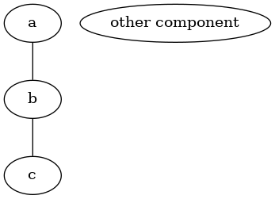

```rust
let mut with_wccs = list.clone();
let component = with_wccs.add_node("other component");
draw_graph(&with_wccs);
```

```rust
println!("Number of weakly connected components: {}", connected_components(&with_wccs));
println!("Are 'a' and 'other component' in same component? {}", has_path_connecting(&with_wccs, item1, component, None));
println!("Are 'a' and 'c' in same component? {}", has_path_connecting(&with_wccs, item1, item3, None))
```

```
Number of weakly connected components: 2
Are 'a' and 'other component' in same component? false
Are 'a' and 'c' in same component? true
```

```
()
```

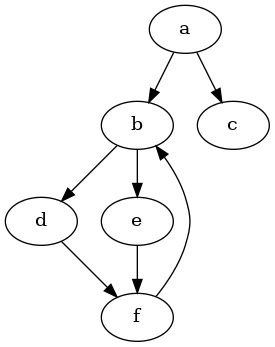

```rust
let mut with_scc = dag.clone();
with_scc.add_edge(dag_item_f, tree_item2, "");
draw_graph(&with_scc);
```

```rust
println!("Does 'with_scc' have strongly connected components? {}", is_cyclic_directed(&with_scc));
println!("Does 'dag' have strongly connected components? {}", is_cyclic_directed(&dag));
```

```
Does 'with_scc' have strongly connected components? true
Does 'dag' have strongly connected components? false
```

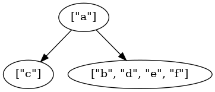

```rust
let  _condensed_graph = condensation(with_scc, true);
let condensed_graph = _condensed_graph.map(
    |_, w| format!("{:?}", w),
    |_, w| w.clone(),
);
draw_graph(&condensed_graph);
```

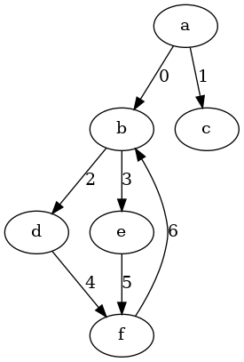

```rust
let _with_scc_and_edge_weights = with_scc.clone();
let with_scc_and_edge_weights = _with_scc_and_edge_weights.map(
    |_, w| w.clone(),
    |i, _| i.index(),
);
draw_graph(&with_scc_and_edge_weights);
```

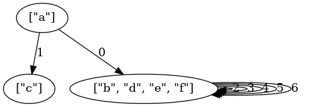

```rust
{
    let  _condensed_graph = condensation(with_scc_and_edge_weights, false);
    let condensed_graph = _condensed_graph.map(
        |_, w| format!("{:?}", w),
        |_, w| format!("{:?}", w),
    );
    draw_graph(&condensed_graph);
}
```

`condensation` takes a graph with strongly connected components and "merges" those components into a single node. If the second argument is `false`, edge weights will be preserved in the form of self loops.

## Using Strongly Connected Components in practice

Lets go back to the DAGs I was talking about earlier. When thinking of DAGs as parallelizable TODO lists, in some cases it can be interesting to turn graphs with cycles into DAGs in order to coax that paralellizable todo list property out of them. I spent a lot of time trying to come up with a good example of this phenomenon.

Imagine you were designing a factory for building planes.

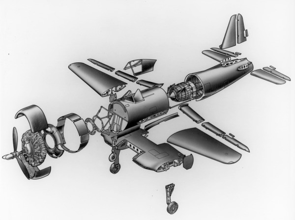

Image from the [San Diego Air & Space Museum - Ray Wagner Collection](https://www.flickr.com/photos/sdasmarchives/20306592858/in/photostream/) Probably public domain

We have a bunch of parts which can be manufactured separately, probably in a different factory, maybe even in a different country, and then we have assembilies of parts, where the parts are connected together. There could be a situation where the Fuselage depended on the lower wing section to be stable and the lower wing section depended on the Fuselage to be stable, this would create a dependency cycle when installing the parts. Such things DO happen in manufacturing, but it is **very impractical** when they do. So engineers try to design planes so that this doesn't happen. It is much better, especially in the old war planes who's diagrams tend to be public domain ;), to be able to manufacture the parts independently. Not having such dependency loops is a major design goal. This means that such situations will be rare, not because of the nature of things, but because we actively avoid their nature.

I considered many possible examples and finally came up with a very frustrating but practical one. In Haskell, I like to organize my code so that each type is in it's own module. I then like to put simple functions that operate on that type in the same file as the type declaration. Unfortunately, I always run into a problem where I get mutually dependent modules. Haskell [doesn't support this very well](https://wiki.haskell.org/Mutually_recursive_modules), and this tends to lead me to rant on the internet and be told by the fanboy trolls that if Haskell doesn't support my usecase, then I'm doing it wrong. I then proceed to put all my util functions in a file called `util.hs` and my types in a file called `types.hs` thus eliminating the need for mutual imports but making my code generally messier and my code files longer. What I'm doing, is manually merging nodes which belong to strongly connected components within my source codes dependency graph. The compiler really should be doing this for me, OR, I could write a rust program which would use petgraph's `condensation` function to combine those Haskell modules which were mutually dependent. That way I could lay out my source code as I see fit, without having to worry about technical limitations of the compiler.

```rust
{
    let  sccs = tarjan_scc(&with_scc_and_edge_weights);
    for scc in sccs {
        println!("----");
        for node_id in scc {
            println!("{}", with_scc_and_edge_weights.node_weight(node_id).unwrap());
        }
    }
}
```

```
----
c
----
d
f
e
b
----
a
```

```
()
```

```rust
// kosaraju is the same as tarjan. Order of nodes within components is always arbitrary.
{
    let  sccs = kosaraju_scc(&with_scc_and_edge_weights);
    for scc in sccs {
        println!("----");
        for node_id in scc {
            println!("{}", with_scc_and_edge_weights.node_weight(node_id).unwrap());
        }
    }
}
```

```
----
c
----
b
d
f
e
----
a
```

```
()
```